Ficha del establecimiento

# Escuela Básica Sendero Del Saber

RBD **9592**San RamónEscuela o liceo

243estudiantes matriculadosCorte Agosto 2026

Mujeres43,6%106 est.

Hombres56,4%137 est.

Chilenos/as61,3%149 est.

Extranjeros/as38,7%94 est.

Actualizada al 05-10-2026

💻Ver ficha completaVersión para computador, con mapas y gráficos interactivos. Pesa varios MB: mejor ábrela con wifi.

🏛️Identificación

## Identificación del establecimiento

Los datos de contacto y las características básicas del establecimiento, tal como están registrados en el Ministerio de Educación. **Si algo está mal o falta, escríbenos** y lo corregimos en la próxima actualización.

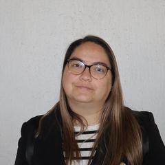

Director o directora

Catalina Vanessa Reyes Pardo

**Nombre**

Escuela Básica Sendero Del Saber

**RBD**

9592

**Dirección**

Carlos Davila 7551

**Comuna**

San Ramón

**Tipo**

Escuela o liceo

**Estado**

✅En funcionamiento

**Director/a**

Catalina Vanessa Reyes Pardo

**Correo**

escuelasenderodelsaber@slepsantarosa.cl

**Teléfono**

443144779

**Sitio web**

WWW.SENDERODELSABERSANRAMON.COM

**Matrícula**

GRATUITO

**Sostenedor**

El sostenedor corresponde a una persona jurídica

**Orientación**

Orientación religiosa Laica

### Niveles que imparte

✓ 🧸 Educación Parvularia✓ 🎒 Enseñanza Básica Niños

### Vulnerabilidad del alumnado

Índice de vulnerabilidad (IVE)

94,7%

Lo calcula JUNAEB y sirve para asignar programas de apoyo.

0%100%

Este establecimientoPromedio de la comuna 86%

Prioritarios en Básica

75,1%

Estudiantes en 1ª, 2ª o 3ª prioridad.

**Un IVE más alto significa más necesidad de apoyo**, no peor calidad. Se usa para decidir a qué establecimientos llegan primero los programas de alimentación, salud y becas.

### Apoyos profesionales al aprendizaje

✓ 📚 Reforzamiento✓ 🧩 Psicopedagogo/a✓ 🧠 Psicólogo/a✓ 👩‍🏫 Profesor/a de educación especial✓ 🤝 Asistente social✓ 🗣️ Fonoaudiólogo/a✓ ➕ Otro: TERAPEUTA OCUPACIONAL, APOYO DES ESCOLARIZACIÓN🧭 Orientador/a🎓 Orientación vocacional

### Infraestructura y atención a la diversidad

✓ 📚 Biblioteca✓ 🔬 Laboratorio✓ 🏛️ Sala multiuso✓ 🌐 Computadores con internet✓ 🖥️ Sala de informática✓ 📽️ Sala audiovisual✓ 🏟️ Cancha deportiva✓ ♿ Accesibilidad NEE✓ ➕ Otra: PATIO PRINCIPAL Y PREBÁSICA💻 Computadores🤾 Gimnasio

Las etiquetas con ✓ son las que el establecimiento declaró en el directorio oficial; las grises no están marcadas.

### Jornada Escolar Completa (JEC)

Cursos con jornada completa

8

Cursos sin jornada completa

2

**Ver curso por curso**

| Grado | Cursos | Jornada |
| --- | --- | --- |
| 1° Básico | 1 | ✅ Con JEC |
| 2° Básico | 1 | ✅ Con JEC |
| 3° Básico | 1 | ✅ Con JEC |
| 4° Básico | 1 | ✅ Con JEC |
| 5° Básico | 1 | ✅ Con JEC |
| 6° Básico | 1 | ✅ Con JEC |
| 7° Básico | 1 | ✅ Con JEC |
| 8° Básico | 1 | ✅ Con JEC |
| Kínder | 1 | — Sin JEC |
| Pre-kínder | 1 | — Sin JEC |

Con **Jornada Escolar Completa** los estudiantes tienen más horas de clases al día y almuerzan en el establecimiento.

### Idiomas

**Inglés en Enseñanza Básica**

Básico

### Certificación ambiental (SNCAE)

El establecimiento no tiene certificación del Sistema Nacional de Certificación Ambiental de Establecimientos Educacionales (SNCAE).

### Concentración de alumnado prioritario

Concentración 2026

49,4%

▼4,63 pts

Porcentaje de estudiantes prioritarios reconocidos por el Mineduc.

0%100%

Concentración del establecimiento

Concentración 2025

54,0%

Resolución exenta

2026

Observación del Ministerio: **Sin ACAP 2025-2026**.

La **concentración de prioritarios** define cuánta Subvención Escolar Preferencial (SEP) recibe el establecimiento. Sobre 60 % da acceso a la asignación por concentración.

### Requisitos para postular

✓ 🎂 Cumplir la edad mínima✓ 📄 Certificado de nacimiento✓ 📊 Certificado de notas✓ 🏠 Ficha de protección social✓ ♿ Informe de necesidades educativas📝 Informe de personalidad🧪 Test de intereses✍️ Firmar el proyecto educativo⚖️ Firmar el reglamento de convivencia📋 Examen de ingreso👥 Entrevista con apoderados🎲 Sorteo💍 Certificado de matrimonio⛪ Certificado de bautismo⛪ Certificado de matrimonio religioso💰 Pago de postulación➕ Otro

Desde el Sistema de Admisión Escolar, los establecimientos públicos **no pueden seleccionar** por rendimiento ni por antecedentes socioeconómicos. Estos son los antecedentes administrativos que el establecimiento declara pedir.

**Equipo del SLEP que acompaña al establecimiento**

**Asesor/a territorial**

RAÚL VASQUEZ DEL PINO

**Correo UTP**

utp.escuelasenderodelsaber@slepsantarosa.cl

**Correo Inspectoría**

inspectoria.escuelasenderodelsaber@slepsantarosa.cl

🏫Matrícula

## Matrícula y asistencia

Cuántos estudiantes tiene el establecimiento, quiénes son y cuántos días van efectivamente a clases. **La asistencia es el porcentaje de días que los estudiantes asistieron** sobre los días en que estuvieron matriculados.

Matrícula · Agosto 2026

243

▼4,0%

Variación desde el primer mes del año escolar.

1141.024

Este establecimientoPromedio del SLEP 333

Asistencia promedio

93,4%

Días asistidos sobre días matriculados.

89,5%93,7%

Este añoPromedio de años anteriores 91,0%

Cursos

10

Niveles

2

Matrícula regular

243

Estudiantes en la modalidad regular del establecimiento.

Matrícula no regular

0

Modalidades de adultos, reingreso o validación de estudios.

Matrícula mes a mes · 2026

Cuántos estudiantes había registrados al cierre de cada mes.

Asistencia mes a mes · 2026

Porcentaje de días asistidos sobre los días en que el estudiante estuvo matriculado.

Matrícula año a año

Matrícula del último mes de cada año escolar.

### Quiénes estudian acá

Por género

Hombres · 137Mujeres · 106

Por origen

Chilenos/as · 149Extranjeros/as · 94Nacionalizados/as · 0

Nacionalidades presentes

Número de estudiantes por país de nacimiento declarado.

🇻🇪 Venezolana50

🌐 Otra16

🇨🇴 Colombiana10

🇭🇹 Haitiana5

🇵🇪 Peruana3

Otros6

Pueblos originarios

Estudiantes que declaran pertenecer a un pueblo originario.

🌿 Mapuche4

🌐 Otra etnia1

### Por nivel de enseñanza

Matrícula por nivel

🧸 Educación Parvularia28

🎒 Enseñanza Básica Niños215

Asistencia por nivel

La escala va de 0 % a 100 %.

🧸 Educación Parvularia87,9%

🎒 Enseñanza Básica Niños94,1%

### Asistencia por grupo

Asistencia por género

Promedio ponderado por el número de estudiantes de cada grupo.

Hombres92,4%

Mujeres94,7%

Asistencia por origen

Chilenos/as91,4%

Extranjeros/as96,6%

Asistencia por nacionalidad

Solo los seis grupos con más estudiantes.

🇨🇱 Chilena91,9%

🇻🇪 Venezolana95,4%

🌐 Otra93,5%

🇨🇴 Colombiana99,5%

🇭🇹 Haitiana100,0%

🇵🇪 Peruana100,0%

Asistencia por pueblo originario

🌿 Mapuche88,1%

🌐 Otra etnia100,0%

**Ver el detalle curso por curso (10 cursos)**

| Curso | Matrícula | Asistencia % |
| --- | --- | --- |
| Pre-kínder A | 14 | 88,8 |
| Kínder A | 14 | 87,1 |
| 1° Básico A | 19 | 91 |
| 2° Básico A | 29 | 95,1 |
| 3° Básico A | 18 | 97,4 |
| 4° Básico A | 22 | 92,2 |
| 5° Básico A | 35 | 95,6 |
| 6° Básico A | 27 | 96,6 |
| 7° Básico A | 36 | 91,4 |
| 8° Básico A | 29 | 94,1 |

**Ver la matrícula año a año, con su variación**

| Periodo | Matrícula | Variación | Cambio |
| --- | --- | --- | --- |
| 2026 | 243 | =0,0 | =0,0% |
| 2025 | 243 | −41,0 | −14,4% |
| 2024 | 284 | =0,0 | =0,0% |
| 2023 | 284 | +33,0 | +13,1% |
| 2022 | 251 | +8,0 | +3,3% |
| 2019 | 243 | +18,0 | +8,0% |
| 2018 | 225 | +17,0 | +8,2% |
| 2017 | 208 | −13,0 | −5,9% |
| 2016 | 221 | — | — |

**Ver la asistencia año a año, con su variación**

| Periodo | Asistencia | Variación | Cambio |
| --- | --- | --- | --- |
| 2026 | 93,4% | +2,0 pts | +2,2% |
| 2025 | 91,4% | +1,6 pts | +1,8% |
| 2024 | 89,8% | =0,0 pts | =0,0% |
| 2023 | 89,8% | −0,5 pts | −0,6% |
| 2022 | 90,3% | −1,1 pts | −1,2% |
| 2019 | 91,4% | −2,0 pts | −2,1% |
| 2018 | 93,4% | +2,5 pts | +2,8% |
| 2017 | 90,9% | +0,1 pts | +0,1% |
| 2016 | 90,8% | — | — |

La matrícula se cuenta al cierre de cada mes, así que los cambios durante el año reflejan traslados y retiros. Corte usado: **Agosto 2026**.

🤝Vida escolar

## Vida escolar y comunidad

Qué actividades ofrece el establecimiento fuera de las clases, cómo se organiza con las familias y quiénes representan a la comunidad. **Las etiquetas con ✓ son las que el establecimiento declaró** en el directorio oficial del Ministerio; las grises no están marcadas.

### Talleres y actividades para estudiantes

✓ 🤝 Convivencia✓ 🚫 Prevención drogas✓ ❤️ Educación sexual✓ 🫂 Acción social✓ ➕ Otra: HPV, JUNAEB Y PRESTACIONES. INSERCIÓN INMIGRANTE🧭 Orientación🌱 Medio ambiente🌟 Vida sana✝️ Pastoral

Actividades de formación: orientación, convivencia, prevención y vida sana.

✓ 🎵 Música✓ 🩰 Danza o ballet✓ 💻 Taller TIC✓ ➕ Otro: ROBÓTICA, SALIDAS PEDAGÓGICAS, T. AUDIOVISUAL🎭 Teatro📚 Literatura✂️ Manualidades🎨 Artes plásticas🎓 Preuniversitario

Talleres de arte, cultura y tecnología fuera del horario de clases.

✓ 🥅 Baby fútbol✓ 🏐 Vóleibol✓ 🏀 Básquetbol✓ ➕ Otro: CIRCO⚽ Fútbol🏃 Atletismo🏊 Natación🤸 Gimnasia🎾 Tenis🏓 Tenis de mesa♟️ Ajedrez

Disciplinas deportivas que ofrece el establecimiento.

### Trabajo con las familias

✓ 👪 Talleres de formación✓ 🎉 Actividades de integración✓ 📈 Perfeccionamiento➕ Otra

✓ 📒 Libreta de comunicaciones✓ 🌐 Web y redes sociales✓ 🗣️ Consejo escolar✓ 📄 Reuniones generales✓ 👥 Entrevistas individuales✓ ➕ Otro: FICHERO

Por dónde el establecimiento se comunica con apoderados y apoderadas.

### Organizaciones de la comunidad

**Centro de Padres**

Constituido

**Personalidad jurídica**

Vigente

**Última elección de directiva**

**Centro de Estudiantes**

Constituido

**Representante del sostenedor en el Consejo Escolar**

Eiden Viera Pardo

**Acompañamiento del Consejo Escolar**

Eiden Viera Pardo

Para contactar al centro de padres o al centro de estudiantes, escribe al establecimiento: sus datos están más arriba.

El **Consejo Escolar** es la instancia donde se juntan dirección, docentes, asistentes, apoderados y estudiantes para conversar sobre la marcha del establecimiento.

### Normativa y conectividad

**Uso de uniforme**

Uniforme propio del establecimiento

**Tipo de conexión**

Fibra óptica

**Velocidad de internet**

Sin información

🧭Gestión

## Instrumentos de gestión: PEI y PME

El **PEI** dice quién quiere ser el establecimiento: su misión, su visión y sus sellos. El **PME** dice qué va a hacer este año para lograrlo, con responsables y presupuesto. Son los dos documentos que ordenan el trabajo.

### Proyecto Educativo Institucional (PEI)

**Misión**

La comunidad educativa Sendero del Saber de San Ramón brinda una educación integral a todos y todas nuestras estudiantes, promoviendo la diversidad cultural de cada uno de ellos, con énfasis en la formación de valores y el desarrollo socio-emocional por medio de la realización de talleres que potencian sus habilidades curriculares, artísticas y deportivas.

**Visión**

Ser una institución educativa comprometida con la niñez que implemente estrategias educativas innovadoras que potencien las habilidades y actitudes de todos los y las estudiantes de forma integral.

### Énfasis declarados, en orden de prioridad

**1º**

Desarrollo integral

**2º**

Artístico

**3º**

Inclusivo

### Documentos oficiales

[📘Proyecto Educativo](https://wwwfs.mineduc.cl/Archivos/infoescuelas/documentos/9592/ProyectoEducativo9592.pdf)[⚖️Reglamento de Convivencia](https://wwwfs.mineduc.cl/Archivos/infoescuelas/documentos/9592/ReglamentodeConvivencia9592.pdf)[📊Reglamento de Evaluación](https://wwwfs.mineduc.cl/Archivos/infoescuelas/documentos/9592/ReglamentoDeEvaluacion9592.pdf)

### Plan de Mejoramiento Educativo (PME)

Acciones comprometidas

18

Inversión total del plan

$ 113.237.389

Dimensiones cubiertas

4

Acciones por dimensión

Las cuatro dimensiones del PME: gestión pedagógica, liderazgo, convivencia y recursos.

Gestión de Recursos6

Gestión Pedagógica5

Convivencia Escolar4

Liderazgo3

Quién lidera las acciones

Los cinco responsables con más acciones a cargo.

Director10

Jefe técnico4

Equipo de gestión2

Encargado de convivencia1

Sostenedor1

De dónde sale el financiamiento

Monto comprometido por fuente de recursos.

sep$ 113.237.389

**Ver las 18 acciones del plan**

| Acción | Dimensión | Responsable | Monto |
| --- | --- | --- | --- |
| Plan de acompañamiento y retroalimentación docente ADECO | Gestión Pedagógica | Equipo de gestión | $ 0 |
| Servicio de Plataforma Educativa | Gestión Pedagógica | Jefe técnico | $ 1.829.210 |
| Plan de transición educativa (DECRETO 373) | Gestión Pedagógica | Jefe técnico | $ 700.000 |
| Extensión horaria para Niveles Sin JEC | Gestión Pedagógica | Jefe técnico | $ 0 |
| Evaluación para el aprendizaje | Gestión Pedagógica | Jefe técnico | $ 0 |
| Contratación de Profesionales para fortalecer la gestión de soporte para los procesos ed. de los EE | Liderazgo | Sostenedor | $ 9.645.874 |
| Gestión Administrativa y Pedagógica | Liderazgo | Director | $ 213.242 |
| Monitoreo PME | Liderazgo | Equipo de gestión | $ 0 |
| Asistencia y resguardo de las trayectorias educativas (Dupla Psicosocial) | Convivencia Escolar | Director | $ 0 |
| Servicio de transporte escolar para salidas pedagógicas y/o actividades extraescolares | Convivencia Escolar | Director | $ 700.000 |
| Talleres extraprogramáticos | Convivencia Escolar | Director | $ 4.762.304 |
| Vida saludable y autocuidado | Convivencia Escolar | Encargado de convivencia | $ 738.767 |
| Uso de recursos didácticos y tecnológicos | Gestión de Recursos | Director | $ 1.768.547 |
| Servicio de equipos multicopiadores para el Apoyo Pedagógico | Gestión de Recursos | Director | $ 2.417.989 |
| Adquisición de Material Escolar para el Apoyo al Aprendizaje | Gestión de Recursos | Director | $ 1.373.201 |
| Contratación de Docentes y/o Asistentes de la Educación para Apoyo Pedagógico | Gestión de Recursos | Director | $ 85.365.989 |
| Ceremonia de reconocimiento a la participación en talleres extraprogramáticos. | Gestión de Recursos | Director | $ 2.000.000 |
| Adquisición de mobiliario escolar | Gestión de Recursos | Director | $ 1.722.266 |

**Ver plazos y estado de ejecución de cada acción**

| Acción | Inicio | Término | Nivel de ejecución |
| --- | --- | --- | --- |
| Plan de acompañamiento y retroalimentación docente ADECO | 01/3/2025 | 15/12/2025 | Implementado de manera adecuada (50% a 74%) |
| Servicio de Plataforma Educativa | 05/3/2025 | 31/12/2025 | Implementado de manera adecuada (50% a 74%) |
| Plan de transición educativa (DECRETO 373) | 03/3/2025 | 31/12/2025 | Implementado parcialmente (25 a 49%) |
| Extensión horaria para Niveles Sin JEC | 03/3/2025 | 31/12/2025 | Implementación avanzada (75% a 99%) |
| Evaluación para el aprendizaje | 03/3/2025 | 31/12/2025 | Implementado parcialmente (25 a 49%) |
| Contratación de Profesionales para fortalecer la gestión de soporte para los procesos ed. de los EE | 01/3/2025 | 31/12/2025 | Implementación avanzada (75% a 99%) |
| Gestión Administrativa y Pedagógica | 03/3/2025 | 31/12/2025 | Implementación avanzada (75% a 99%) |
| Monitoreo PME | 03/3/2025 | 31/12/2025 | Implementación avanzada (75% a 99%) |
| Asistencia y resguardo de las trayectorias educativas (Dupla Psicosocial) | 03/3/2025 | 31/12/2025 | Implementado parcialmente (25 a 49%) |
| Servicio de transporte escolar para salidas pedagógicas y/o actividades extraescolares | 03/3/2025 | 31/12/2025 | Implementado de manera adecuada (50% a 74%) |
| Talleres extraprogramáticos | 03/3/2025 | 31/12/2025 | Implementación avanzada (75% a 99%) |
| Vida saludable y autocuidado | 03/3/2025 | 31/12/2025 | Implementación avanzada (75% a 99%) |
| Uso de recursos didácticos y tecnológicos | 03/3/2025 | 31/12/2025 | Implementación avanzada (75% a 99%) |
| Servicio de equipos multicopiadores para el Apoyo Pedagógico | 03/3/2025 | 31/12/2025 | Implementado (100%) |
| Adquisición de Material Escolar para el Apoyo al Aprendizaje | 01/3/2025 | 31/12/2025 | Implementado parcialmente (25 a 49%) |
| Contratación de Docentes y/o Asistentes de la Educación para Apoyo Pedagógico | 03/3/2025 | 31/12/2025 | Implementado (100%) |
| Ceremonia de reconocimiento a la participación en talleres extraprogramáticos. | 03/3/2025 | 31/12/2025 | Implementado inicialmente (1% a 24%) |
| Adquisición de mobiliario escolar | 12/6/2025 | 31/12/2025 | No Implementado (0%) |

**Ver estrategia, programa y medios de verificación**

| Acción | Estrategia | Programa asociado | Medios de verificación |
| --- | --- | --- | --- |
| Plan de acompañamiento y retroalimentación docente ADECO | Implementar comunidades de aprendizaje profesional donde los docentes participen en ciclos de reflexión y retroalimentación continua a partir del acompañamiento al aula | Ninguno | -Planificación comunidades de aprendizajes -Acta de retroalimentación -Pautas de acompañamiento |
| Servicio de Plataforma Educativa | Implementar comunidades de aprendizaje profesional donde los docentes participen en ciclos de reflexión y retroalimentación continua a partir del acompañamiento al aula | SEP | -Reportes -Informe de calificaciones -Informe de uso de la plataforma |
| Plan de transición educativa (DECRETO 373) | Implementar comunidades de aprendizaje profesional donde los docentes participen en ciclos de reflexión y retroalimentación continua a partir del acompañamiento al aula | SEP | -? Plan de transición |
| Extensión horaria para Niveles Sin JEC | Implementar comunidades de aprendizaje profesional donde los docentes participen en ciclos de reflexión y retroalimentación continua a partir del acompañamiento al aula | SEP | -Asistencia -Plan de trabajo |
| Evaluación para el aprendizaje | Implementar comunidades de aprendizaje profesional donde los docentes participen en ciclos de reflexión y retroalimentación continua a partir del acompañamiento al aula | SEP | -Registro de revisión y retroalimentación de rubricas docentes -Actas de reflexión pedagógica -Encuestas |
| Contratación de Profesionales para fortalecer la gestión de soporte para los procesos ed. de los EE | Fomentar el liderazgo distribuido con un enfoque en la toma de decisiones basada en datos y mejora continua. | SEP | -Informes de avances y ejecución -Convenio de prestación de servicios |
| Gestión Administrativa y Pedagógica | Fomentar el liderazgo distribuido con un enfoque en la toma de decisiones basada en datos y mejora continua. | SEP | -Calendario de actividades -Actas de reuniones de monitoreo -Planilla de monitoreo y seguimiento administrativo |
| Monitoreo PME | Fomentar el liderazgo distribuido con un enfoque en la toma de decisiones basada en datos y mejora continua. | SEP | -Actas -Planilla de seguimiento de acciones -Reportes PME |
| Asistencia y resguardo de las trayectorias educativas (Dupla Psicosocial) | Aumentando la participación a las actividades planificadas en el plan de gestión de la convivencia | SEP | -Informe de impacto -Plan de trabajo -Bitácora y/o actas de trabajo |
| Servicio de transporte escolar para salidas pedagógicas y/o actividades extraescolares | Aumentando la participación a las actividades planificadas en el plan de gestión de la convivencia | SEP | -? Formulario C -Protocolo de seguridad -Programa salidas pedagógicas |
| Talleres extraprogramáticos | Aumentando la participación a las actividades planificadas en el plan de gestión de la convivencia | SEP | -Planificaciones -Encuesta de satisfacción de los talleres realizados -Registro de asistencia |
| Vida saludable y autocuidado | Aumentando la participación a las actividades planificadas en el plan de gestión de la convivencia | SEP | -Registro fotografico -Informes de encuestas -Actas -Articulación con redes externas -Planificaciones -Listas de asistencia |
| Uso de recursos didácticos y tecnológicos | Optimizar el uso de recursos tecnológicos mediante la capacitación docente y su integración en el aula. | SEP | -Bitácora de uso CRA y enlaces. -Planificaciones |
| Servicio de equipos multicopiadores para el Apoyo Pedagógico | Optimizar el uso de recursos tecnológicos mediante la capacitación docente y su integración en el aula. | SEP | -Registro de material impreso -Contrato suministro -Informe de impresiones mensuales |
| Adquisición de Material Escolar para el Apoyo al Aprendizaje | Optimizar el uso de recursos tecnológicos mediante la capacitación docente y su integración en el aula. | SEP | -Facturas -Procesos de compras públicas |
| Contratación de Docentes y/o Asistentes de la Educación para Apoyo Pedagógico | Optimizar el uso de recursos tecnológicos mediante la capacitación docente y su integración en el aula. | SEP | -Registro de asistencia -Plan de trabajo |
| Ceremonia de reconocimiento a la participación en talleres extraprogramáticos. | Optimizar el uso de recursos tecnológicos mediante la capacitación docente y su integración en el aula. | SEP | -Listas de asistencia a talleres -Nóminas de estudiantes premiados -Protocolo de premiación |
| Adquisición de mobiliario escolar | Optimizar el uso de recursos tecnológicos mediante la capacitación docente y su integración en el aula. | Ninguno | -Encuestas -Factura -Solicitud de compra |

**Ver la descripción completa y la justificación de cada acción**

| Acción | Qué se hace | Por qué |
| --- | --- | --- |
| Plan de acompañamiento y retroalimentación docente ADECO | Fortalecer las prácticas pedagógicas mediante un mínimo de tres sesiones anuales de acompañamiento, que incluyan observación de aula, retroalimentación periódica y formación de comunidades de aprendiz… | El nivel de implementación está dentro del curso adecuado en relación a las fechas programadas. |
| Servicio de Plataforma Educativa | La plataforma educativa es una herramienta digital que facilita la planificación, implementación y seguimiento con un enfoque pedagógico. Su propósito es fortalecer la gestión curricular y didáctica, … | El nivel de implementación está dentro del curso adecuado en relación a las fechas programadas. |
| Plan de transición educativa (DECRETO 373) | Plan de acción que tiene como propósito fundamental promover y resguardar el traspaso entre el nivel NT2 y 1º Básico. | Ciertas condiciones relacionadas con el tiempo, los recursos humanos y/o materiales o la infraestructura no permitieron la adecuada implementación de la actividad. |
| Extensión horaria para Niveles Sin JEC | La extensión horaria de profesionales y técnicos brinda a los estudiantes acceso a herramientas de aprendizaje y experiencias educativas lúdicas y enriquecedoras. Estas se desarrollan en espacios peda… | El nivel de implementación está dentro del curso adecuado en relación a las fechas programadas. |
| Evaluación para el aprendizaje | Fortalecer el sistema de evaluación basado en en el decreto 67. Este enfoque implica el diseño e implementación de estrategias de evaluación que se centren en el proceso de aprendizaje, brindando retr… | Ciertas condiciones relacionadas con el tiempo, los recursos humanos y/o materiales o la infraestructura no permitieron la adecuada implementación de la actividad. |
| Contratación de Profesionales para fortalecer la gestión de soporte para los procesos ed. de los EE | Contratación de profesionales especializados para fortalecer la gestión educativa en los EE, optimizando planificación, seguimiento y evaluación pedagógica. Su labor mejora la enseñanza, acompaña a do… | El nivel de implementación está dentro del curso adecuado en relación a las fechas programadas. |
| Gestión Administrativa y Pedagógica | Implementación de un sistema de seguimiento y monitoreo de la gestión institucional mediante un cronograma de trabajo claro y compartido, que permita cautelar el cumplimiento de los objetivos del PME.… | El nivel de implementación está dentro del curso adecuado en relación a las fechas programadas. |
| Monitoreo PME | La dirección junto con el equipo de gestión realizara el monitoreo y seguimiento de las acciones tres veces en el año escolar con el propósito de tomar decisiones y ajustes de tiempo. | El nivel de implementación está dentro del curso adecuado en relación a las fechas programadas. |
| Asistencia y resguardo de las trayectorias educativas (Dupla Psicosocial) | Contratación de especialistas psicosociales para fortalecer el acompañamiento integral de estudiantes y garantizar su continuidad educativa. Se implementan estrategias que favorecen el acceso, asisten… | Ciertas condiciones relacionadas con el tiempo, los recursos humanos y/o materiales o la infraestructura no permitieron la adecuada implementación de la actividad. |
| Servicio de transporte escolar para salidas pedagógicas y/o actividades extraescolares | El transporte escolar para salidas pedagógicas y extraescolares facilita el acceso a experiencias fuera del aula, enriqueciendo la formación integral. Visitas a espacios culturales, científicos y comu… | El nivel de implementación está dentro del curso adecuado en relación a las fechas programadas. |
| Talleres extraprogramáticos | Planificación y realización de talleres deportivos, culturales y artísticos, para promover una educación integral, generar mayor pertenencia con el establecimiento, mejorando el clima y la sana conviv… | El nivel de implementación está dentro del curso adecuado en relación a las fechas programadas. |
| Vida saludable y autocuidado | El equipo de Convivencia Educativa fomentará la buena convivencia, el respeto y el autocuidado en la comunidad educativa mediante talleres preventivos. Se reforzarán espacios de promoción y prevención… | El nivel de implementación está dentro del curso adecuado en relación a las fechas programadas. |
| Uso de recursos didácticos y tecnológicos | Los docentes desarrollan sus estrategias utilizando variados recursos didácticos y tecnológicos, los cuales están incorporados en las planificaciones, evaluaciones y desarrollo de sus clases. | El nivel de implementación está dentro del curso adecuado en relación a las fechas programadas. |
| Servicio de equipos multicopiadores para el Apoyo Pedagógico | Contratación de un servicio de multicopiado para la impresión de material didáctico de calidad, con el objetivo de fortalecer los pro-cesos de enseñanza y aprendizaje de los estudiantes. Este servicio… | El nivel de implementación está dentro del curso adecuado en relación a las fechas programadas. |
| Adquisición de Material Escolar para el Apoyo al Aprendizaje | Adquisición de material escolar y pedagógico para garantizar el acceso equitativo a recursos de calidad, promoviendo la participación estudiantil, la motivación y el aprendizaje activo. Estos insumos … | El nivel de implementación está dentro del curso adecuado en relación a las fechas programadas. |
| Contratación de Docentes y/o Asistentes de la Educación para Apoyo Pedagógico | Contratación de docentes y asistentes de la educación para fortalecer los procesos pedagógicos y brindar acompañamiento especializado. Su labor permite implementar estrategias de enseñanza, apoyar la … | El nivel de implementación está dentro del curso adecuado en relación a las fechas programadas. |
| Ceremonia de reconocimiento a la participación en talleres extraprogramáticos. | Organizar una ceremonia de premiación semestral para reconocer a estudiantes que hayan participado activamente en talleres extraprogramáticos para reforzar el sentido de pertenencia y valorar el esfue… | El nivel de implementación está dentro del curso adecuado en relación a las fechas programadas. |
| Adquisición de mobiliario escolar | Adquisición de mobiliario escolar adecuado y funcional para aulas, espacios comunes y áreas específicas del establecimiento educacional. Esta acción busca renovar o complementar el equipamiento existe… | El nivel de implementación está dentro del curso adecuado en relación a las fechas programadas. |

🏆SNED

## SNED · Sistema Nacional de Evaluación del Desempeño

El SNED evalúa cada dos años el desempeño de los establecimientos municipales y particulares subvencionados. Mira **seis factores**: efectividad, superación, igualdad de oportunidades, iniciativa, integración y mejoramiento.

⚪No seleccionado

Índice SNED del establecimiento

Va de 0 a 100 y resume los seis factores que evalúa el sistema.

Los seis factores, uno por uno

Cada factor va de 0 a 100. Los de arriba pesan más en el índice final.

Efectividad46,9%

Superación55,0%

Igualdad de oportunidades91,5%

Iniciativa83,5%

Integración71,4%

Mejoramiento99,3%

**¿Cuánto pesa cada factor?**

| Factor | Puntaje | Peso en el índice (%) |
| --- | --- | --- |
| Efectividad | 46,9 | 37 |
| Superación | 55 | 28 |
| Igualdad de oportunidades | 91,5 | 22 |
| Iniciativa | 83,5 | 6 |
| Integración | 71,4 | 5 |
| Mejoramiento | 99,3 | 2 |

El SNED premia con un bono a los equipos de los establecimientos con mejor desempeño dentro de un grupo de escuelas parecidas. **No es una nota**: compara con establecimientos de condiciones similares, no con todo Chile.

💼Ocupación

## Ocupación de cupos

Cuántos de los cupos que el establecimiento ofreció están efectivamente ocupados. **Se calcula dividiendo la matrícula actual por los cupos declarados** en el Sistema de Admisión Escolar (SAE).

🚨Con muchos cupos disponibles

Ocupación de los cupos

La marca gris señala el 100 %: por sobre esa línea hay más estudiantes que cupos declarados.

Cupos declarados (SAE)

420

Matrícula al corte

243

Agosto 2026

Cupos libres

177

Cupos que quedan sin usar.

Vacantes en el curso de ingreso

31

**Ver los cupos declarados por grado**

| Grado | Cursos | Cupos |
| --- | --- | --- |
| 1° Básico | 1 | 45 |
| 2° Básico | 1 | 45 |
| 3° Básico | 1 | 45 |
| 4° Básico | 1 | 45 |
| 5° Básico | 1 | 45 |
| 6° Básico | 1 | 45 |
| 7° Básico | 1 | 45 |
| 8° Básico | 1 | 45 |
| Kínder | 1 | 30 |
| Pre-kínder | 1 | 30 |

La ocupación compara la **matrícula efectiva** con los **cupos que el establecimiento declaró** en el Sistema de Admisión Escolar. Una ocupación baja no siempre es mala: puede ser espacio para crecer.

♿PIE

## Programa de Integración Escolar (PIE)

Cuántos estudiantes reciben apoyos del PIE y qué tipo de apoyo necesitan. Las **necesidades permanentes** acompañan toda la trayectoria escolar; las **transitorias** requieren apoyo por un tiempo determinado.

Estudiantes en PIE · 2026

47

Se cuenta cada estudiante una sola vez.

0,0%40,0%

Porcentaje de la matrícula

NEE permanentes

12

Acompañan toda la trayectoria escolar.

NEE transitorias

35

Requieren apoyo por un tiempo acotado.

Sobre la matrícula

19,3%

Tipo de necesidad educativa

NEE permanentes · 12NEE transitorias · 35

Por género

Hombres · 29Mujeres · 18

Diagnósticos más frecuentes

Los ocho diagnósticos con más estudiantes.

Trastorno del Lenguaje13

Dificultades Específicas del Aprendizaje10

Funcionamiento Intelectual Limítrofe9

Trastorno del Espectro Autista9

Trastorno de Déficit Atencional3

Discapacidad Intelectual2

Hipoacusia Moderada1

En qué cursos están

2° Básico7

6° Básico7

7° Básico6

3° Básico5

8° Básico5

Kínder5

1° Básico4

4° Básico4

5° Básico4

Por nivel de enseñanza

Enseñanza Básica Niños42

Educación Parvularia5

**Ver el cruce entre género y tipo de necesidad**

| Genero | PERMANENTE | TRANSITORIO |
| --- | --- | --- |
| Femenino | 3 | 15 |
| Masculino | 9 | 20 |

**Ver el cruce entre género y los diagnósticos más frecuentes**

| Genero | Dificultades Específicas del Aprendizaje | Funcionamiento Intelectual Limítrofe | Trastorno del Espectro Autista | Trastorno del Lenguaje | Trastorno de Déficit Atencional |
| --- | --- | --- | --- | --- | --- |
| Femenino | 3 | 4 | 2 | 8 | 0 |
| Masculino | 7 | 5 | 7 | 5 | 3 |

**Ver todos los diagnósticos registrados**

| Diagnóstico | Tipo de NEE | Estudiantes |
| --- | --- | --- |
| Trastorno del Lenguaje | TRANSITORIO | 13 |
| Dificultades Específicas del Aprendizaje | TRANSITORIO | 10 |
| Funcionamiento Intelectual Limítrofe | TRANSITORIO | 9 |
| Trastorno del Espectro Autista | PERMANENTE | 9 |
| Trastorno de Déficit Atencional | TRANSITORIO | 3 |
| Discapacidad Intelectual | PERMANENTE | 2 |
| Hipoacusia Moderada | PERMANENTE | 1 |

### Postulaciones al programa, por período

Estudiantes por año y período

El período **Regular** es la postulación anual; **Extraordinario** y **Excepcionalidad** son cupos que se abren después.

2026 · Excepcionalidad5

2026 · Extraordinario8

2026 · Regular58

2025 · Excepcionalidad4

2025 · Regular65

2024 · Regular + Excepcionalidad75

**Ver el detalle por año, período y tipo de necesidad**

| Año | Período | Tipo de NEE | Estudiantes |
| --- | --- | --- | --- |
| 2.026 | Excepcionalidad | PERMANENTE | 5 |
| 2.026 | Extraordinario | PERMANENTE | 3 |
| 2.026 | Extraordinario | TRANSITORIO | 5 |
| 2.026 | Regular | PERMANENTE | 13 |
| 2.026 | Regular | TRANSITORIO | 45 |
| 2.025 | Excepcionalidad | PERMANENTE | 4 |
| 2.025 | Regular | PERMANENTE | 16 |
| 2.025 | Regular | TRANSITORIO | 49 |
| 2.024 | Regular + Excepcionalidad | PERMANENTE | 25 |
| 2.024 | Regular + Excepcionalidad | TRANSITORIO | 50 |

Evolución del programa

Fuente: base territorial del Área de Inclusión Educativa del SLEP.

El PIE entrega apoyos dentro del aula a estudiantes con necesidades educativas especiales. **Estar en PIE no es un diagnóstico permanente**: muchas necesidades son transitorias y se superan con apoyo.

🔄Retiros

## Retiros y movilidad estudiantil

Cuántos estudiantes se retiraron del establecimiento, cuándo y hacia dónde. **Lo importante es saber si volvieron a matricularse en otra parte**: quienes no lo hicieron son los casos que hay que buscar.

Retiros en 2026

27

Equivale al 11,1% de la matrícula actual.

Ya están en otro establecimiento

11

Se confirmó matrícula posterior.

Sin matrícula vigente

2

Requieren seguimiento: pueden estar fuera del sistema.

Pendiente en SIGE

14

Todavía sin información de destino.

En qué meses se producen

Tipo de movimiento

Sin matrícula14

Cambio a otro EE fuera del SLEP13

A qué establecimientos se van

Los seis destinos más frecuentes.

Sin destino informado14

Colegio Sochides3

Escuela Novomar2

Escuela Partic Parroquial Domingo Savio2

Chilean Eagles College - La Cisterna1

Escuela Bas. Los Heroes De Yungay1

Desde qué cursos

7° Básico7

5° Básico6

2° Básico3

1° Básico2

3° Básico2

4° Básico2

8° Básico2

Kínder2

Pre-kínder1

Qué tipo de establecimiento eligieron

Dependencia del establecimiento de destino.

Sin Matrícula14

Particular Subvencionado11

Otro Slep2

A qué comunas se fueron

Sin información14

Puente Alto5

San Ramón4

La Granja2

La Cisterna1

La Pintana1

**Ver todos los destinos, uno por uno**

| Establecimiento | Comuna | Dependencia | Estudiantes |
| --- | --- | --- | --- |
| Sin destino informado | — | Sin Matrícula | 14 |
| Colegio Sochides | Puente Alto | Particular Subvencionado | 3 |
| Escuela Novomar | Puente Alto | Particular Subvencionado | 2 |
| Escuela Partic Parroquial Domingo Savio | San Ramón | Particular Subvencionado | 2 |
| Chilean Eagles College - La Cisterna | La Cisterna | Particular Subvencionado | 1 |
| Escuela Bas. Los Heroes De Yungay | La Granja | Otro Slep | 1 |
| Escuela Basica Part Gratuita Casa Azul | La Granja | Particular Subvencionado | 1 |
| Escuela Basica Particular Armi | San Ramón | Particular Subvencionado | 1 |
| Escuela Particular Francisco De Miranda | San Ramón | Particular Subvencionado | 1 |
| Liceo N523 | La Pintana | Otro Slep | 1 |

Un retiro no siempre es una pérdida: muchas veces la familia se cambia de comuna. Lo que sí requiere seguimiento son los estudiantes **sin matrícula vigente** en ningún otro establecimiento.

📚Resultados

## Resultados educativos

Cómo les fue a los estudiantes en sus notas y cuántos pasaron de curso. El **promedio general** va de 1,0 a 7,0 y la **tasa de aprobación** es el porcentaje de estudiantes que fue promovido al curso siguiente.

Promedio general · 2025

5,9de 7,0

Promedio de todas las notas finales, ponderado por el tamaño de cada curso.

5,46,3

Este establecimientoPromedio del SLEP 5,9

Tasa de aprobación

97,3%

Promovidos sobre el total de estudiantes con situación final.

50%100%

Este establecimientoPromedio del SLEP 97%

Estudiantes promovidos

215

Estudiantes reprobados

6

Cómo terminó el año 2025

Situación final de cada estudiante al cierre del año escolar.

Promovidos · 215Reprobados · 6Retirados · 11Trasladados · 14

Promedio general año a año

Escala de notas de 1,0 a 7,0.

Tasa de aprobación año a año

Porcentaje de estudiantes promovidos.

**Ver el detalle por curso (8 grados)**

| Grado | Estudiantes | Promedio | Aprobación % |
| --- | --- | --- | --- |
| 1° Básico | 25 | 6,1 | 100 |
| 2° Básico | 22 | 5,9 | 95 |
| 3° Básico | 28 | 5,6 | 96 |
| 4° Básico | 32 | 5,7 | 96,6 |
| 5° Básico | 27 | 6,1 | 95,5 |
| 6° Básico | 43 | 5,9 | 97,5 |
| 7° Básico | 30 | 5,8 | 100 |
| 8° Básico | 39 | 6,1 | 97,2 |

### Aprobación por grupo

Tasa de aprobación por género

Masculino97,4%

Femenino97,1%

Tasa de aprobación por origen

Chileno96,0%

Extranjero99,0%

**Ver el promedio de notas por grupo**

| Género | Estudiantes | Promedio | Aprobación % |
| --- | --- | --- | --- |
| Masculino | 128 | 5,9 | 97,4 |
| Femenino | 118 | 5,9 | 97,1 |

| Origen | Estudiantes | Promedio | Aprobación % |
| --- | --- | --- | --- |
| Chileno | 131 | 5,8 | 96 |
| Extranjero | 115 | 6 | 99 |

### Cómo terminó cada año

Año 2025

Promovidos · 215Reprobados · 6Retirados · 11Trasladados · 14

Año 2024

Año 2023

Año 2022

**Ver la tabla de situación final año a año**

| Año | Promovidos | Reprobados | Retirados | Trasladados |
| --- | --- | --- | --- | --- |
| 2.025 | 215 | 6 | 11 | 14 |
| 2.024 | 244 | 7 | 5 | 16 |
| 2.023 | 242 | 9 | 18 | 16 |
| 2.022 | 214 | 11 | 20 | 34 |

**Ver el promedio y la aprobación año a año**

| Periodo | Promedio | Variación | Cambio |
| --- | --- | --- | --- |
| 2025 | 5,9 | −0,1 | −1,0% |
| 2024 | 6,0 | −0,0 | −0,3% |
| 2023 | 6,0 | +0,1 | +1,9% |
| 2022 | 5,9 | — | — |

| Periodo | Aprobación | Variación | Cambio |
| --- | --- | --- | --- |
| 2025 | 97,3% | +0,1 pts | +0,1% |
| 2024 | 97,2% | +0,8 pts | +0,8% |
| 2023 | 96,4% | +1,3 pts | +1,4% |
| 2022 | 95,1% | — | — |

La tasa de aprobación deja fuera a quienes se retiraron o se trasladaron durante el año: **solo considera a quienes terminaron el año en el establecimiento**.

📐SIMCE

## SIMCE

El SIMCE es la prueba que aplica la Agencia de Calidad para saber cuánto aprendieron los estudiantes en Lectura y Matemática. Además del puntaje, muestra **cuántos estudiantes quedaron en cada nivel de aprendizaje**: Insuficiente, Elemental o Adecuado.

### Categoría de desempeño

⚠️Básica 2019: MEDIO-BAJO

La categoría de desempeño la asigna la Agencia de Calidad y considera resultados **y** el contexto social del establecimiento. Va de Alto a Insuficiente.

### Resultados por curso

Última medición disponible: **2025**.

Lectura

257pts

▼4 pts

Variación respecto de la medición anterior.

218264

Última mediciónPromedio de años anteriores 238

Matemática

223pts

▼27 pts

Variación respecto de la medición anterior.

219257

Última mediciónPromedio de años anteriores 240

### ¿El cambio es real?

•Lectura ■Sin cambio significativo•Matemática ▼Baja de forma significativa

La Agencia de Calidad indica si la diferencia con la medición anterior es **estadísticamente significativa**. Si no lo es, el cambio puede deberse al azar.

Niveles de aprendizaje · Lectura

Porcentaje de estudiantes en cada nivel de logro.

Insuficiente · 40,0%Elemental · 20,0%Adecuado · 40,0%

Niveles de aprendizaje · Matemática

Porcentaje de estudiantes en cada nivel de logro.

Insuficiente · 62,5%Elemental · 29,2%Adecuado · 8,3%

Evolución de los puntajes

Puntaje promedio del establecimiento en cada medición.

LecturaMatemática

**Comparar con establecimientos de condiciones parecidas**

| Prueba | Este establecimiento | Grupo de comparación | Diferencia |
| --- | --- | --- | --- |
| Lectura | 257 | 267 | −10 pts |
| Matemática | 223 | 252 | −29 pts |

El grupo de comparación reúne establecimientos con estudiantes de condiciones socioeconómicas similares.

**Ver todos los puntajes históricos**

| Prueba | Año | Puntaje | Estudiantes |
| --- | --- | --- | --- |
| Lectura | 2016 | 225 | 17 |
| Lectura | 2017 | 243 | 20 |
| Lectura | 2018 | 232 | 21 |
| Lectura | 2022 | 221 | 19 |
| Lectura | 2023 | 249 | 29 |
| Lectura | 2024 | 261 | 21 |
| Lectura | 2025 | 257 | — |
| Matemática | 2016 | 242 | 17 |
| Matemática | 2017 | 254 | 20 |
| Matemática | 2018 | 231 | 20 |
| Matemática | 2022 | 222 | 19 |
| Matemática | 2023 | 238 | 28 |
| Matemática | 2024 | 250 | 22 |
| Matemática | 2025 | 223 | — |

Los puntajes SIMCE van aproximadamente de 100 a 400. Una diferencia de menos de 10 puntos entre dos años **no suele ser significativa**: conviene mirar la tendencia de varios años, no el salto de uno.

🌱IDPS

## Indicadores de Desarrollo Personal y Social

Los IDPS miden cosas que no salen en una prueba: si los estudiantes se sienten capaces de aprender, si el ambiente es sano, si participan y si tienen hábitos saludables. **Van de 0 a 100** y se comparan con establecimientos de condiciones parecidas.

Última medición disponible: **2025**.

Autoestima académica y motivación escolar

67de 100

▲3 pts

Variación respecto de la medición anterior.

0100

Este establecimientoEstablecimientos parecidos 76

Clima de convivencia escolar

74de 100

▲4 pts

Variación respecto de la medición anterior.

0100

Este establecimientoEstablecimientos parecidos 76

Hábitos de vida saludable

69de 100

▲2 pts

Variación respecto de la medición anterior.

0100

Este establecimientoEstablecimientos parecidos 71

Participación y formación ciudadana

76de 100

▲4 pts

Variación respecto de la medición anterior.

0100

Este establecimientoEstablecimientos parecidos 79

### ¿El cambio es real?

•Autoestima académica y motivación escolar ■Sin cambio significativo•Clima de convivencia escolar ▲Sube de forma significativa•Hábitos de vida saludable ■Sin cambio significativo•Participación y formación ciudadana ■Sin cambio significativo

Evolución de los cuatro indicadores

Autoestima académica y motivación escolarClima de convivencia escolarParticipación y formación ciudadanaHábitos de vida saludable

**Ver todos los puntajes históricos y su grupo de comparación**

| Indicador | Año | Puntaje | Grupo de comparación |
| --- | --- | --- | --- |
| Autoestima académica y motivación escolar | 2025 | 67 | 76 |
| Clima de convivencia escolar | 2025 | 74 | 76 |
| Hábitos de vida saludable | 2025 | 69 | 71 |
| Participación y formación ciudadana | 2025 | 76 | 79 |
| Autoestima académica y motivación escolar | 2024 | 64 | 75 |
| Clima de convivencia escolar | 2024 | 70 | 75 |
| Hábitos de vida saludable | 2024 | 67 | 71 |
| Participación y formación ciudadana | 2024 | 72 | 79 |
| Autoestima académica y motivación escolar | 2023 | 75 | — |
| Clima de convivencia escolar | 2023 | 77 | — |
| Hábitos de vida saludable | 2023 | 74 | — |
| Participación y formación ciudadana | 2023 | 82 | — |
| Autoestima académica y motivación escolar | 2022 | 75 | — |
| Clima de convivencia escolar | 2022 | 75 | — |
| Hábitos de vida saludable | 2022 | 67 | — |
| Participación y formación ciudadana | 2022 | 77 | — |
| Autoestima académica y motivación escolar | 2018 | 76 | — |
| Clima de convivencia escolar | 2018 | 68 | — |
| Hábitos de vida saludable | 2018 | 64 | — |
| Participación y formación ciudadana | 2018 | 75 | — |
| Autoestima académica y motivación escolar | 2017 | 68 | — |
| Clima de convivencia escolar | 2017 | 68 | — |
| Hábitos de vida saludable | 2017 | 61 | — |
| Participación y formación ciudadana | 2017 | 75 | — |
| Autoestima académica y motivación escolar | 2016 | 68 | — |
| Clima de convivencia escolar | 2016 | 71 | — |
| Hábitos de vida saludable | 2016 | 59 | — |
| Participación y formación ciudadana | 2016 | 65 | — |

Los IDPS se construyen con encuestas a estudiantes, docentes y apoderados. Van de 0 a 100 y **pesan un 33 % en la categoría de desempeño** que la Agencia de Calidad asigna al establecimiento.

📄DIA

## DIA de cierre

El Diagnóstico Integral de Aprendizajes (DIA) se aplica al cierre del año para ver qué aprendieron los estudiantes. **No pone notas**: clasifica a cada estudiante en un nivel de logro para orientar el trabajo del año siguiente.

Estudiantes evaluados

146

Aplicación 2025

En nivel 1 (inicial)

65

En nivel 2 (intermedio)

78

En nivel 3 (adecuado)

3

Cursos evaluados

6

Cómo se reparten los niveles de logro

Cuántos estudiantes quedaron en cada nivel.

Nivel 1 · inicial · 65Nivel 2 · intermedio · 78Nivel 3 · adecuado · 3

Logro promedio por eje de la prueba

Porcentaje de respuestas correctas en cada eje evaluado.

Números y operaciones48,0%

Patrones y álgebra45,7%

Geometría47,1%

Datos y probabilidades37,3%

**Ver el detalle por curso (6 cursos)**

| Curso | Estudiantes | Nivel I | Nivel II | Nivel III |
| --- | --- | --- | --- | --- |
| 3° Básico | 23 | 7 | 15 | 1 |
| 4° Básico | 25 | 12 | 12 | 1 |
| 5° Básico | 17 | 10 | 7 | 0 |
| 6° Básico | 33 | 8 | 24 | 1 |
| 7° Básico | 20 | 5 | 15 | 0 |
| 8° Básico | 28 | 23 | 5 | 0 |

El DIA es una evaluación **de diagnóstico, no una calificación**: sirve para que el equipo docente sepa dónde reforzar. Los niveles van de 1 (requiere más apoyo) a 3 (logro adecuado).

📈PAES

## PAES

La PAES es la prueba que se rinde para postular a la educación superior. Aquí verás **cuántos estudiantes la rindieron** y qué puntaje promedio obtuvieron, comparado con el promedio del SLEP y el nacional.

📭**Este establecimiento no tiene resultados PAES.**La PAES la rinden solo los establecimientos con enseñanza media.

🎓Ed. superior

## Tránsito a la educación superior

Qué pasó con los estudiantes después de egresar: cuántos entraron a una universidad, instituto profesional o centro de formación técnica, y qué estudian. **Se mira el año inmediatamente siguiente al egreso**.

📭**Todavía no hay seguimiento de egresados para este establecimiento.**El seguimiento se construye cruzando los egresados con las matrículas de educación superior.

🛠️Técnico profesional

## Técnico profesional: especialidades y titulación

Qué especialidades técnicas ofrece el establecimiento, cómo les va a los estudiantes de cada una y cuántos alcanzan el **título técnico de nivel medio** después de hacer su práctica profesional.

📭**Este establecimiento no imparte educación técnico-profesional.**Solo entrega formación humanístico-científica o de enseñanza básica.

👔Funcionarios

## Funcionarios del establecimiento

Cuántas personas trabajan en el establecimiento y en qué. La **dotación estable** son quienes tienen contrato titular o a contrata; los **reemplazos** cubren licencias y permisos, así que un número alto puede indicar rotación.

Corte: **Mayo de 2026**.

Funcionarios y funcionarias

45

Personas distintas con contrato vigente.

Dotación estable

41

Titulares y a contrata, sin contar reemplazos.

En reemplazo

4

Es el 8,9% de la dotación.

Jornada promedio

34,6hrs

Horas semanales contratadas.

Docentes y asistentes de la educación

DOCENTE25

ASISTENTE DE LA EDUCACION20

Por función

Las ocho funciones con más personas.

DOCENTES18

AUXILIARES DE SERVICIO6

PROFESIONALES Y TECNICOS DE APOYO (PIE/SEP/SALUD)6

TECNICOS EN PARVULOS4

EDUCADORA DE PARVULOS3

ASISTENTES DE AULA E INSPECTORIA2

COORDINADORES Y SOPORTE ADM.2

DIRECTIVOS2

Composición de la dotación

Docentes y asistentes de la educación, estables y en reemplazo.

Docente estable · 23Asistente estable · 18Asistente en reemplazo · 2Docente en reemplazo · 2

Dotación mes a mes · 2026

Número de contratos vigentes en cada mes.

Dotación mes a mes por categoría

Asistente en reemplazoAsistente estableDocente en reemplazoDocente estable

**Ver el detalle por cargo (19 combinaciones)**

| Cargo o función | Tipo de hora | Personas | Jornada (hrs) |
| --- | --- | --- | --- |
| DOCENTES | TITULAR | 13 | 36,3 |
| AUXILIARES DE SERVICIO | TITULAR | 4 | 44 |
| DOCENTES | CONTRATA | 4 | 17,5 |
| PROFESIONALES Y TECNICOS DE APOYO (PIE/SEP/SALUD) | TITULAR | 4 | 36,5 |
| TECNICOS EN PARVULOS | TITULAR | 3 | 44 |
| ASISTENTES DE AULA E INSPECTORIA | TITULAR | 2 | 44 |
| COORDINADORES Y SOPORTE ADM. | TITULAR | 2 | 33 |
| DIRECTIVOS | TITULAR | 2 | 44 |
| ADMINISTRATIVOS | TITULAR | 1 | 44 |
| AUXILIARES DE SERVICIO | CONTRATA | 1 | 44 |
| AUXILIARES DE SERVICIO | REEMPLAZO | 1 | 44 |
| DIRECTORES | CONTRATA | 1 | 4 |
| DOCENTES | REEMPLAZO | 1 | 9 |
| EDUCADORA DE PARVULOS | CONTRATA | 1 | 41 |
| EDUCADORA DE PARVULOS | REEMPLAZO | 1 | 41 |
| EDUCADORA DE PARVULOS | TITULAR | 1 | 33 |
| PROFESIONALES Y TECNICOS DE APOYO (PIE/SEP/SALUD) | CONTRATA | 1 | 30 |
| PROFESIONALES Y TECNICOS DE APOYO (PIE/SEP/SALUD) | REEMPLAZO | 1 | 14 |
| TECNICOS EN PARVULOS | CONTRATA | 1 | 14 |

👩‍🏫Carrera docente

## Desarrollo profesional docente

En qué tramo de la Carrera Docente están los profesores y profesoras del establecimiento. Los tramos van de **Acceso** (quienes recién empiezan) a **Experto II**, y dependen de la experiencia y de la evaluación docente.

Corte: **Mayo de 2026**.

Docentes

18

En reemplazo

1

Sin encasillar

0

Es el 0,0% del cuerpo docente.

0%100%

Porcentaje sin encasillar

Docentes por tramo de la Carrera Docente

Los tramos van de Acceso (recién iniciados) a Experto II.

Acceso1

Inicial6

Temprano3

Avanzado6

Experto i2

El tramo lo asigna el Sistema de Desarrollo Profesional Docente según la experiencia y los resultados de la evaluación. **Estar sin encasillar no es una falta**: suele pasar con quienes recién ingresan o están en proceso de evaluación.

🏢Convenios

## Convenios y uso de espacios

Qué organizaciones externas usan las instalaciones del establecimiento fuera del horario de clases, para qué y hasta cuándo.

📭**No hay convenios de uso de espacios registrados.**Se registran acá los acuerdos con clubes, juntas de vecinos u otras organizaciones que usan las instalaciones.

📣Denuncias

## Denuncias y reclamos

Los reclamos que las familias y la comunidad presentaron sobre el establecimiento, por dos vías: **directamente al SLEP** o ante la **Superintendencia de Educación**, que es el organismo fiscalizador.

### Denuncias recibidas por el SLEP

No hay denuncias internas registradas para este establecimiento.

### Denuncias ante la Superintendencia de Educación

Denuncias recibidas

2

Cerradas

1

Pendientes

1

Denuncias por año

Ámbito de la denuncia

CONVIVENCIA1

GESTIÓN TÉCNICO-ADMINISTRATIVA1

Tema específico

PERSONAL DEL ESTABLECIMIENTO EDUCATIVO1

SITUACIONES DE CONNOTACIÓN SEXUAL1

Por dónde entró la denuncia

Portal web2

**Ver los 2 casos uno por uno**

| Fecha | Tema | Afectado | Estado |
| --- | --- | --- | --- |
| 11-09-2025 | SITUACIONES DE CONNOTACIÓN SEXUAL | ESTUDIANTE | Cerrado |
| 11-06-2025 | PERSONAL DEL ESTABLECIMIENTO EDUCATIVO | APODERADO(A) / PADRE O MADRE / TUTOR(A) | Pendiente |

**Ver el detalle del sub-tema de cada denuncia**

| Fecha | Subtema |
| --- | --- |
| 11-09-2025 | SITUACIONES DE CONNOTACIÓN SEXUAL ENTRE PÁRVULOS Y/O ESTUDIANTES |
| 11-06-2025 | INCUMPLIMIENTO DE LOS REQUISITOS DE IDONEIDAD MORAL Y/O PSICOLÓGICA DEL PERSONAL DEL ESTABLECIMIENTO (PERSONAL INHABILITADO PARA TRABAJAR CON MENORES DE EDAD) |

### Procesos administrativos

Procesos registrados

1

En tramitación

0

Resultado en primera instancia

Multa ley 20.5291

Una denuncia **no es una sanción**: es un reclamo que se investiga. Muchas se cierran sin encontrar falta. Lo que importa es que exista el canal y que los casos se tramiten.

👮Seguridad

## Robos y delitos

Los robos y daños que ha sufrido el establecimiento, cuándo ocurrieron y cuánto costaron. **Sirve para decidir dónde reforzar la seguridad**: cámaras, cierres perimetrales o rondas.

📭**No se registran robos ni delitos en este establecimiento.**Buena noticia: no hay incidentes informados a la unidad de seguridad del SLEP.

📍Ubicación

## Ubicación y entorno

Dónde está el establecimiento, desde dónde llegan sus estudiantes y cómo es el barrio que lo rodea. **Toca el botón para abrir la ubicación** en la aplicación de mapas de tu teléfono.

**Dirección**

Carlos Davila 7551

**Comuna**

San Ramón

**Región**

RM

**Zona**

Urbana

**Latitud**

-33,52660

**Longitud**

-70,63856

[📍Abrir en Google Maps](https://www.google.com/maps/search/?api=1&query=-33.52660334,-70.63856408)

### Dónde viven los estudiantes

Distancia promedio al colegio

2,5km

Distancia en línea recta desde el domicilio.

0,0 km15,0 km

Promedio del establecimiento

Domicilios ubicados

146

Niñas y jóvenes mujeres

2,3km

Niños y jóvenes hombres

2,6km

Estudiantes chilenos/as

2,2km

De qué comuna vienen

Misma comuna · 81Otra comuna del SLEP · 11Fuera del SLEP · 54

A qué distancia viven

Número de estudiantes en cada tramo de distancia.

Hasta 1 km81

1 a 3 km24

3 a 5 km15

Más de 5 km26

Las distancias son **en línea recta**, no el recorrido real. Se excluyen los domicilios a más de 30 km, que suelen ser errores de geocodificación. No se publican direcciones individuales.

### El barrio alrededor del establecimiento

Niños y jóvenes en la comuna

15.161

Personas de 0 a 17 años según el Censo 2024.

De 0 a 5 años

4.039

De 6 a 13 años

7.267

De 14 a 17 años

3.855

Población migrante en la comuna

7,6%

5.659 personas de 74.802 habitantes.

0%50%

Porcentaje de la comuna

Escolaridad promedio

9,0años

Años de estudio de los mayores de 18 años.

Población en edad escolar de la comuna

Censo 2024, 822 manzanas de San Ramón.

0 a 5 años4.039

6 a 13 años7.267

14 a 17 años3.855

Estos son datos del **Censo 2024 de toda la comuna**, no del establecimiento. Sirven para dimensionar cuántos niños y jóvenes viven en el territorio.

Esta es la versión para celular, con lo esencial. La **ficha completa** tiene todas las secciones, los gráficos interactivos y los mapas; se ve mejor en un computador.

Ver ficha completa